# HW-week#3

2022-09-24

```r
library(tidyverse)
```

```r
library(ggplot2)
library(dplyr)
library(nycflights13)
```

```r
flights_data <- flights
```

1.How many flights have a missing dep_time? What other variables are missing? What might these rows represent?

```r
flights %>%
  filter(is.na(dep_time)) %>%
  count()
```

```
## # A tibble: 1 × 1
##       n
##   <int>
## 1  8255
```

```r
missed_dep_flights <- filter(flights, is.na(dep_time))
colnames(missed_dep_flights)[colSums(is.na(missed_dep_flights)) > 0]
```

```
## [1] "dep_time"  "dep_delay" "arr_time"  "arr_delay" "tailnum"   "air_time"
```

There are 8255 flights with missing departure time, among these flights, the variables dep_delay, arr_time, arr_delay, tailname, and air_time are also missing.These rows might represent the flights that have never departed.

2.Currently dep_time and sched_dep_time are convenient to look at, but hard to compute with because they’re not really continuous numbers. Convert them to a more convenient representation of number of minutes since midnight.

```r
flights %>%
  transmute(dep_time,  #departure time
            dep_hour = dep_time %/% 100,  #departure hour
         dep_minute = dep_time %% 100,    #departure minute
         dep_time_in_minutes = dep_hour * 60 + dep_minute,  #representation of departure time in minutes
         sched_dep_time,  #scheduled departure time
         sched_dep_hour = sched_dep_time %/% 100,   #scheduled departure hour
         sched_dep_minute = sched_dep_time %% 100,  #scheduled departure minute
         sched_dep_time_in_minutes = sched_dep_hour * 60 + sched_dep_minute)  #representation of scheduled departure time in minutes
```

```
## # A tibble: 336,776 × 8
##    dep_time dep_hour dep_minute dep_time_in_mi…¹ sched…² sched…³ sched…⁴ sched…⁵
##       <int>    <dbl>      <dbl>            <dbl>   <int>   <dbl>   <dbl>   <dbl>
##  1      517        5         17              317     515       5      15     315
##  2      533        5         33              333     529       5      29     329
##  3      542        5         42              342     540       5      40     340
##  4      544        5         44              344     545       5      45     345
##  5      554        5         54              354     600       6       0     360
##  6      554        5         54              354     558       5      58     358
##  7      555        5         55              355     600       6       0     360
##  8      557        5         57              357     600       6       0     360
##  9      557        5         57              357     600       6       0     360
## 10      558        5         58              358     600       6       0     360
## # … with 336,766 more rows, and abbreviated variable names
## #   ¹dep_time_in_minutes, ²sched_dep_time, ³sched_dep_hour, ⁴sched_dep_minute,
## #   ⁵sched_dep_time_in_minutes
```

The more convenient format of departure time representation is shown in the tibble above.

3.Look at the number of canceled flights per day. Is there a pattern? Is the proportion of canceled flights related to the average delay? Use multiple dyplr operations, all on one line, concluding with ggplot(aes(x= ,y=)) + geom_point()

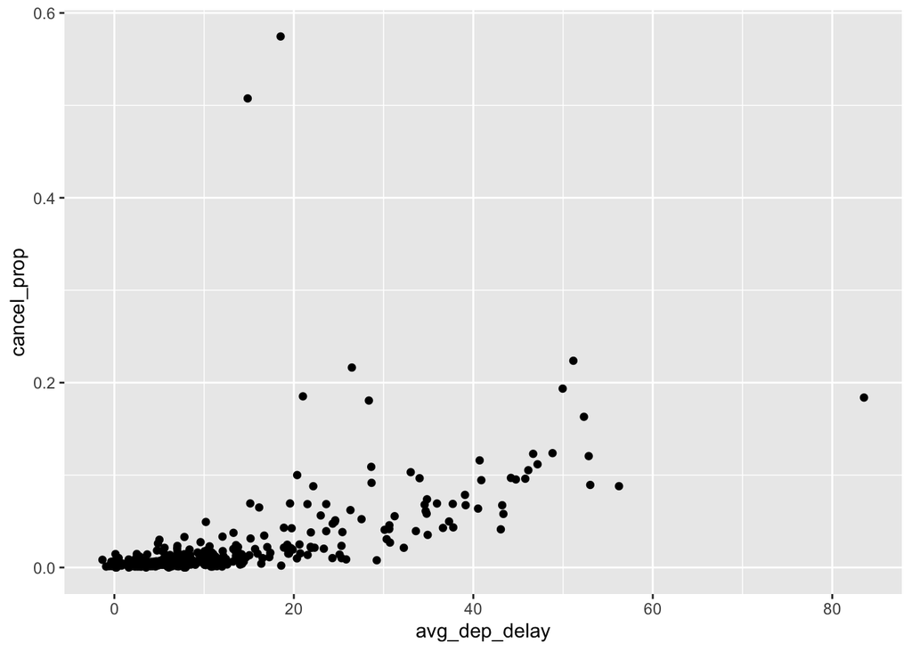

```r
#The canceled flights are defined as the flights that never departed (with a missing dep_time)
flights %>%
  group_by(year, month, day) %>%
  summarize(cancel_count = sum(is.na(dep_time)),
            cancel_prop = cancel_count / n(),
            avg_dep_delay = mean(dep_delay, na.rm = TRUE)) %>%
  ggplot(aes(x = avg_dep_delay, y = cancel_prop)) + geom_point()
```

According the graph, we see a general trend that the greater the average departure delay, the larger the proportion of flights cancelled. There seems a pattern of positive correlation between these two variables.